# Action Asymmetry Pilot: Analyses

Owen Morgan

November 12, 2022

## Demographics

Demographics

Summary

| N | Age (years) | Education (years) | Sex (M/F/O) | EHI |
| --- | --- | --- | --- | --- |
| 103 | 29.48 (5.98) | 14.45 (2.48) | 51/51/1 | 89.81 (14.62) |

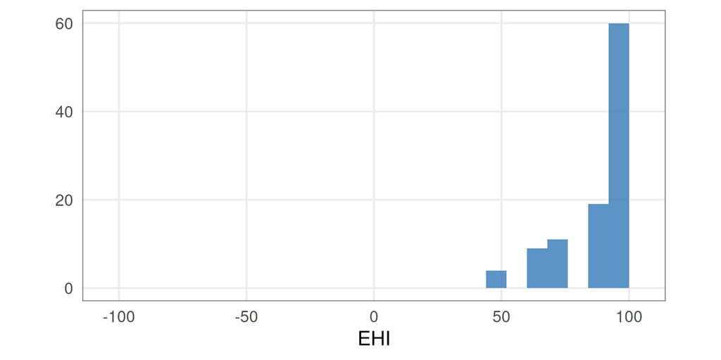

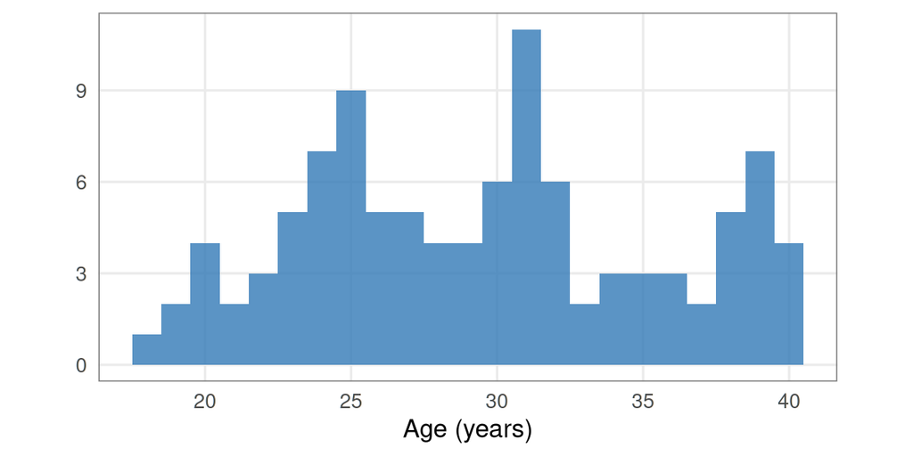

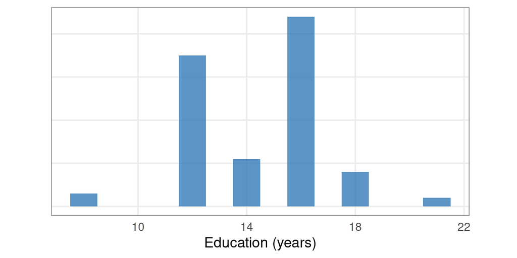

| Race | n |
| --- | --- |
| White | 78 |
| Black or African American | 12 |
| Asian | 7 |
| Multiple | 5 |
| American Indian or Alaska Native | 1 |

| Hispanic ethnicity | n |
| --- | --- |
| No | 90 |
| Yes | 13 |

## Field x Level

### Reaction time

#### Plots

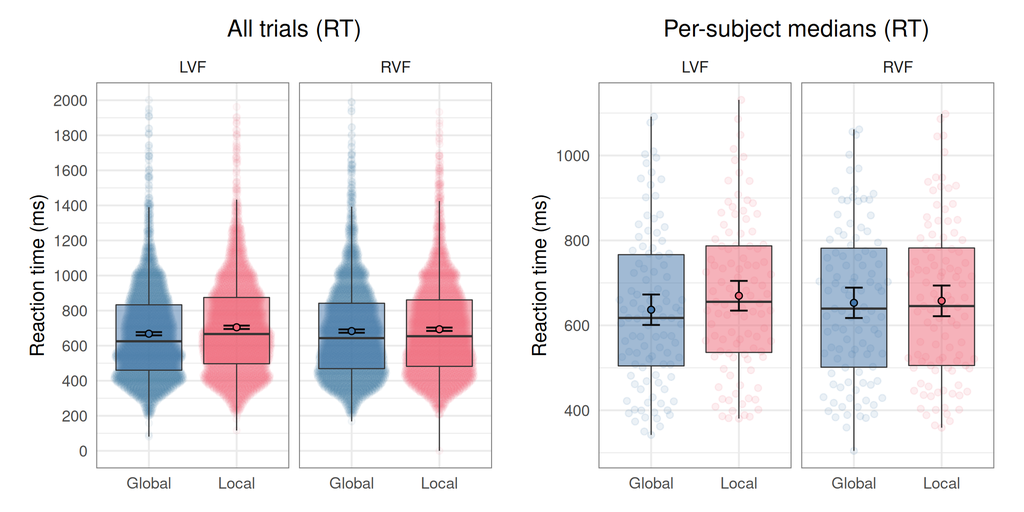

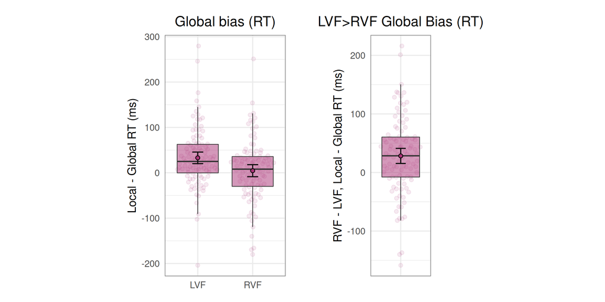

#### Statistics

##### Simple mixed regression model

Reaction time is modeled as a linear effect of field and level, using data from every target-present trial with a “go” response:  
`lmer( rt ~ field + level + field:level + (1 | subject) )`  
*Discussion question*: Should any variables not-of-interest be included as covariates? E.g., sex, target (circle/square), first block (z or slash), overall median rt (ms).

Field by level interaction (RT)

ANOVA: compare models with vs. without interaction term

| npar | AIC | BIC | logLik | deviance | Chisq | Df | p.value |
| --- | --- | --- | --- | --- | --- | --- | --- |
| 5 | 169,498.804 | 169,535.96 | −84,744.402 | 169,488.804 | - | - | - |
| 6 | 169,486.498 | 169,531.086 | −84,737.249 | 169,474.498 | 14.306 | 1 | .0002 |

Field by level interaction (RT)

Omnibus F-test

| term | df | sumsq | meansq | statistic | p.value |
| --- | --- | --- | --- | --- | --- |
| field | 1 | 16,115.006 | 16,115.006 | 0.218 | .64 |
| level | 1 | 1,724,296.922 | 1,724,296.922 | 23.285 | <.0001 |
| field:level | 1 | 537,042.46 | 537,042.46 | 7.252 | .007 |
| Residuals | 12,469 | 923,341,332.508 | 74,050.953 | - | - |

Field by level interaction (RT)

Compare effect estimate to zero with emmeans()

| field_consec | level_consec | estimate<sup>1</sup> | SE | df<sup>2</sup> | lower.CL<sup>3</sup> | upper.CL | t.ratio | p.value<sup>4</sup> |
| --- | --- | --- | --- | --- | --- | --- | --- | --- |
| LVF - RVF | Local - Global | 28.74 | 7.597 | 12,367.148 | 13.848 | 43.632 | 3.783 | .0002 |

<sup>1</sup> A positive number means global bias is stronger in LVF (as predicted for right handers)  
<sup>2</sup> Degrees-of-freedom method: kenward-roger  
<sup>3</sup> Confidence level: 95%  
<sup>4</sup> Two-sided

Global bias by field (RT)

| contrast | estimate<sup>1</sup> | SE | df<sup>2</sup> | lower.CL<sup>3</sup> | upper.CL | t.ratio | p.value<sup>4</sup> |
| --- | --- | --- | --- | --- | --- | --- | --- |
| LVF Local - LVF Global | 37.344 | 5.371 | 12,367.401 | 26.817 | 47.871 | 6.953 | <.0001 |
| RVF Local - RVF Global | 8.604 | 5.378 | 12,367.493 | −1.938 | 19.145 | 1.6 | .11 |

<sup>1</sup> A positive number means global bias (faster RT for global)  
<sup>2</sup> Degrees-of-freedom method: kenward-roger  
<sup>3</sup> Confidence level: 95%  
<sup>4</sup> Two-sided, uncorrected

RT estimates by field and level (from model)

| field | level | emmean | SE | df<sup>1</sup> | lower.CL<sup>2</sup> | upper.CL |
| --- | --- | --- | --- | --- | --- | --- |
| LVF | Global | 669.856 | 17.258 | 109.603 | 635.653 | 704.058 |
| LVF | Local | 707.199 | 17.275 | 110.036 | 672.965 | 741.434 |
| RVF | Global | 685.996 | 17.264 | 109.748 | 651.783 | 720.21 |
| RVF | Local | 694.6 | 17.271 | 109.941 | 660.372 | 728.828 |

<sup>1</sup> Degrees-of-freedom method: kenward-roger  
<sup>2</sup> Confidence level: 95%

RT estimates by field and level (descriptive)

| field | level | median | mean | SE |
| --- | --- | --- | --- | --- |
| LVF | Global | 625 | 668.172 | 4.727 |
| LVF | Local | 666.5 | 704.799 | 4.966 |
| RVF | Global | 643 | 683.259 | 4.898 |
| RVF | Local | 654 | 693.636 | 4.906 |

##### Mixed regression model with covariates: sex, age, target, response key.

Reaction time is modeled as a linear effect of field and level, using data from every target-present trial with a “go” response:  
`lmer( rt ~ field*level*sex + field*level*age + field*level*target + field*level*block_response + field*level + field + level + sex + age + target + block_response + (1 | subject), data = aah_for_rt_model )`  
*Discussion question*: What should be included as covariates? E.g., sex, age, target (circle/square), first block (z or slash), overall median rt (ms). Should we use the pilot to test which variables-not-of interest should be included in the main experiment analysis? What variables could plausibly influence (1) the field x level interaction, and (2) more importantly, the field x level x handedness interaction? Am I specifying the model correctly, giving what we want to test?

Field by level interaction (RT)

ANOVA: compare models with vs. without interaction term

| npar | AIC | BIC | logLik | deviance | Chisq | Df | p.value |
| --- | --- | --- | --- | --- | --- | --- | --- |
| 17 | 167,662.288 | 167,788.447 | −83,814.144 | 167,628.288 | - | - | - |
| 18 | 167,649.97 | 167,783.55 | −83,806.985 | 167,613.97 | 14.318 | 1 | .0002 |

Field by level interaction (RT)

Omnibus F-test

| term | df | sumsq | meansq | statistic | p.value |
| --- | --- | --- | --- | --- | --- |
| field | 1 | 17,427.577 | 17,427.577 | 0.242 | .62 |
| level | 1 | 1,783,130.248 | 1,783,130.248 | 24.777 | <.0001 |
| sex | 1 | 63,625.488 | 63,625.488 | 0.884 | .35 |
| age | 1 | 15,293,603.296 | 15,293,603.296 | 212.505 | <.0001 |
| target | 1 | 6,600,092.792 | 6,600,092.792 | 91.708 | <.0001 |
| block_response | 1 | 447,181.776 | 447,181.776 | 6.214 | .01 |
| field:level | 1 | 556,470.233 | 556,470.233 | 7.732 | .005 |
| field:sex | 1 | 28,812.195 | 28,812.195 | 0.4 | .53 |
| level:sex | 1 | 499,429.312 | 499,429.312 | 6.94 | .008 |
| field:age | 1 | 611.191 | 611.191 | 0.008 | .93 |
| level:age | 1 | 59,376.071 | 59,376.071 | 0.825 | .36 |
| field:target | 1 | 6,501.259 | 6,501.259 | 0.09 | .76 |
| level:target | 1 | 1,414,194.463 | 1,414,194.463 | 19.65 | <.0001 |
| field:block_response | 1 | 322,075.686 | 322,075.686 | 4.475 | .03 |
| level:block_response | 1 | 15,303.527 | 15,303.527 | 0.213 | .64 |
| field:level:sex | 1 | 4,418.856 | 4,418.856 | 0.061 | .8 |
| field:level:age | 1 | 7,450.854 | 7,450.854 | 0.104 | .75 |
| field:level:target | 1 | 78,857.157 | 78,857.157 | 1.096 | .3 |
| field:level:block_response | 1 | 97,476.599 | 97,476.599 | 1.354 | .24 |
| Residuals | 12,326 | 887,079,737.465 | 71,968.176 | - | - |

Field by level interaction (RT)

Compare effect estimate to zero with emmeans()

| field_consec | level_consec | estimate<sup>1</sup> | SE | df<sup>2</sup> | lower.CL<sup>3</sup> | upper.CL | t.ratio | p.value<sup>4</sup> |
| --- | --- | --- | --- | --- | --- | --- | --- | --- |
| LVF - RVF | Local - Global | 29.123 | 7.603 | 12,227.155 | 14.22 | 44.027 | 3.83 | .0001 |

<sup>1</sup> A positive number means global bias is stronger in LVF (as predicted for right handers)  
<sup>2</sup> Degrees-of-freedom method: kenward-roger  
<sup>3</sup> Confidence level: 95%  
<sup>4</sup> Two-sided

Global bias by field (RT)

| contrast | estimate<sup>1</sup> | SE | df<sup>2</sup> | lower.CL<sup>3</sup> | upper.CL | t.ratio | p.value<sup>4</sup> |
| --- | --- | --- | --- | --- | --- | --- | --- |
| LVF Local - LVF Global | 39.256 | 5.374 | 12,227.418 | 28.721 | 49.79 | 7.305 | <.0001 |
| RVF Local - RVF Global | 10.132 | 5.383 | 12,227.526 | −0.419 | 20.683 | 1.882 | .06 |

<sup>1</sup> A positive number means global bias (faster RT for global)  
<sup>2</sup> Degrees-of-freedom method: kenward-roger  
<sup>3</sup> Confidence level: 95%  
<sup>4</sup> Two-sided, uncorrected

**Investigate the possible interaction of target x level x field. Is one shape (the circles?) easier to see when global? Does one shape (the more visible circles?) have a weaker laterality effect?**

Field by level by target interaction (RT)

Compare effect estimate to zero with emmeans()

| field_consec | level_consec | target_consec | estimate<sup>1</sup> | SE | df<sup>2</sup> | asymp.LCL<sup>3</sup> | asymp.UCL<sup>3</sup> | z.ratio | p.value<sup>4</sup> |
| --- | --- | --- | --- | --- | --- | --- | --- | --- | --- |
| LVF - RVF | Local - Global | square - circle | 23.008 | 15.206 | Inf | −6.796 | 52.812 | 1.513 | .13 |

<sup>1</sup> A positive number means LVF global bias (the predicted effect for right handers) is stronger for squares  
<sup>2</sup> Degrees-of-freedom method: kenward-roger  
<sup>3</sup> Confidence level: 95%  
<sup>4</sup> Two-sided

Field by level by target interaction (RT)

Compare effect estimate to zero with emmeans()

| field_consec | level_consec | target | estimate<sup>1</sup> | SE | df<sup>2</sup> | asymp.LCL<sup>3</sup> | asymp.UCL<sup>3</sup> | z.ratio | p.value<sup>4</sup> |
| --- | --- | --- | --- | --- | --- | --- | --- | --- | --- |
| LVF - RVF | Local - Global | circle | 17.619 | 10.597 | Inf | −3.15 | 38.389 | 1.663 | .1 |
| LVF - RVF | Local - Global | square | 40.627 | 10.906 | Inf | 19.252 | 62.002 | 3.725 | .0002 |

<sup>1</sup> A positive number means LVF global bias (the predicted effect for right handers)  
<sup>2</sup> Degrees-of-freedom method: kenward-roger  
<sup>3</sup> Confidence level: 95%  
<sup>4</sup> Two-sided

LVF global bias by target (RT)

| contrast | target | estimate<sup>1</sup> | SE | df<sup>2</sup> | asymp.LCL<sup>3</sup> | asymp.UCL<sup>3</sup> | z.ratio | p.value<sup>4</sup> |
| --- | --- | --- | --- | --- | --- | --- | --- | --- |
| LVF Local - LVF Global | circle | 11.621 | 7.499 | Inf | −3.077 | 26.319 | 1.55 | .12 |
| RVF Local - RVF Global | circle | −5.999 | 7.489 | Inf | −20.677 | 8.68 | −0.801 | .42 |
| LVF Local - LVF Global | square | 66.89 | 7.698 | Inf | 51.803 | 81.977 | 8.69 | <.0001 |
| RVF Local - RVF Global | square | 26.263 | 7.731 | Inf | 11.111 | 41.415 | 3.397 | .0007 |

<sup>1</sup> A positive number means global bias (faster RT for global)  
<sup>2</sup> Degrees-of-freedom method: kenward-roger  
<sup>3</sup> Confidence level: 95%  
<sup>4</sup> Two-sided, uncorrected

Global bias by target (RT)

| contrast | target | estimate<sup>1</sup> | SE | df<sup>2</sup> | asymp.LCL<sup>3</sup> | asymp.UCL<sup>3</sup> | z.ratio | p.value<sup>4</sup> |
| --- | --- | --- | --- | --- | --- | --- | --- | --- |
| Local - Global | circle | 2.811 | 5.3 | Inf | −7.577 | 13.199 | 0.53 | .6 |
| Local - Global | square | 46.577 | 5.457 | Inf | 35.882 | 57.272 | 8.536 | <.0001 |

<sup>1</sup> A positive number means global bias (faster RT for global)  
<sup>2</sup> Degrees-of-freedom method: kenward-roger  
<sup>3</sup> Confidence level: 95%  
<sup>4</sup> Two-sided, uncorrected

Effect of target on RT

| contrast | estimate<sup>1</sup> | SE | df<sup>2</sup> | asymp.LCL<sup>3</sup> | asymp.UCL<sup>3</sup> | z.ratio | p.value<sup>4</sup> |
| --- | --- | --- | --- | --- | --- | --- | --- |
| square - circle | 49.051 | 3.803 | Inf | 41.597 | 56.504 | 12.898 | <.0001 |

<sup>1</sup> A positive number means global bias (faster RT for global)  
<sup>2</sup> Degrees-of-freedom method: kenward-roger  
<sup>3</sup> Confidence level: 95%  
<sup>4</sup> Two-sided, uncorrected

### Accuracy

#### Plots

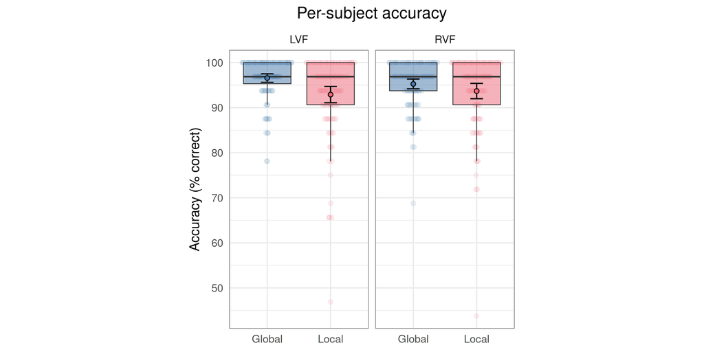

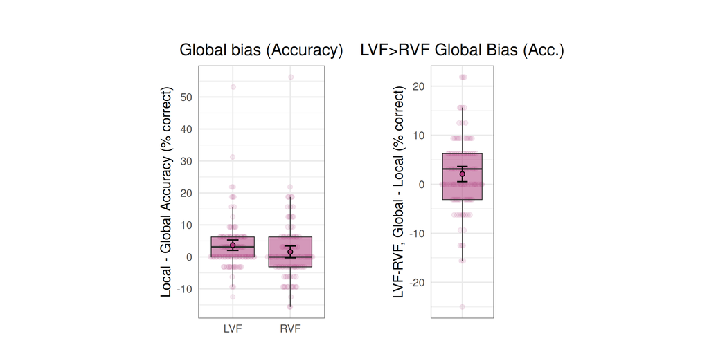

#### Statistics

##### Simple mixed regression model

Accuracy is modeled as a binomial effect of field and level, using binary correct/incorrect data from every target-present trial:  
`glmer( correct ~ field + level + field:level + (1 | subject), family = "binomial" )`

Field by level interaction (Accuracy)

ANOVA: compare models with vs. without interaction term

| npar | AIC | BIC | logLik | deviance | Chisq | Df | Pr(>Chisq) |
| --- | --- | --- | --- | --- | --- | --- | --- |
| 4 | 5,138.642 | 5,168.589 | −2,565.321 | 5,130.642 | - | - | - |
| 5 | 5,131.864 | 5,169.298 | −2,560.932 | 5,121.864 | 8.778 | 1 | 0.003 |

Field by level interaction (Accuracy)

Compare effect estimate to zero with emmeans()

| field_consec | level_consec | odds.ratio<sup>1</sup> | SE | df<sup>2</sup> | asymp.LCL<sup>3</sup> | asymp.UCL | null | z.ratio | p.value<sup>4</sup> |
| --- | --- | --- | --- | --- | --- | --- | --- | --- | --- |
| RVF / LVF | Local / Global | 1.622 | 0.261 | Inf | 1.184 | 2.223 | 1 | 3.009 | .003 |

<sup>1</sup> Backtransformed to odds ratio from log odds ratio (tests are performed on log odds ratio scale). A ratio > 1 means global bias is stronger in the LVF, as predicted for right handers.  
<sup>2</sup> I don't understand why df is 'Inf' here, but I think it is expected when emmeans does logistic regression. See emmeans FAQ: https://cran.r-project.org/web/packages/emmeans/vignettes/FAQs.html#asymp.  
<sup>3</sup> Confidence level: 95%  
<sup>4</sup> Two-sided

Global bias by field (Accuracy)

| contrast | odds.ratio<sup>1</sup> | SE | df | asymp.LCL<sup>2</sup> | asymp.UCL | null | z.ratio | p.value<sup>3</sup> |
| --- | --- | --- | --- | --- | --- | --- | --- | --- |
| LVF Global / LVF Local | 2.235 | 0.263 | Inf | 1.774 | 2.815 | 1 | 6.832 | <.0001 |
| RVF Global / RVF Local | 1.378 | 0.151 | Inf | 1.111 | 1.708 | 1 | 2.924 | .003 |

<sup>1</sup> Backtransformed to odds ratio from log odds ratio (tests are performed on log odds ratio scale). A ratio > 1 means global bias (more correct responses for global).  
<sup>2</sup> Confidence level: 95%  
<sup>3</sup> Two-sided, uncorrected

Accuracy estimates by field and level (from model)

| field | level | prob<sup>1</sup> | SE | df | asymp.LCL<sup>2</sup> | asymp.UCL |
| --- | --- | --- | --- | --- | --- | --- |
| LVF | Global | 0.977 | 0.003 | Inf | 0.97 | 0.983 |
| LVF | Local | 0.95 | 0.006 | Inf | 0.937 | 0.96 |
| RVF | Global | 0.968 | 0.004 | Inf | 0.959 | 0.975 |
| RVF | Local | 0.956 | 0.005 | Inf | 0.945 | 0.965 |

<sup>1</sup> Back-transformed to probability (% correct) from logit scale  
<sup>2</sup> Confidence level: 95%

Accuracy estimates by field and level (descriptive)

| field | level | mean_subject_percent_correct |
| --- | --- | --- |
| LVF | Global | 96.572 |
| LVF | Local | 92.9 |
| RVF | Global | 95.267 |
| RVF | Local | 93.689 |

##### Mixed regression model with covariates: sex, age, target, response key.

Accuracy is modeled as a linear effect of field and level, using data from every target-present trial with a “go” response. The full model did not converge:  
`glmer( correct ~ field*level*sex + field*level*age + field*level*target + field*level*block_response + field*level + field + level + sex + age + target + block_response + (1 | subject), data = aah_for_acc_model, family = "binomial")`  
So, this analysis uses a smaller model with combinations of field x level x target as predictors:  
`glmer( correct ~ field*level*target + (1 | subject), data = aah_for_acc_model, family = "binomial" )`  
*Discussion question*: What should be included as covariates? E.g., sex, age, target (circle/square), first block (z or slash), overall median rt (ms). Should we use the pilot to test which variables-not-of interest should be included in the main experiment analysis? What variables could plausibly influence (1) the field x level interaction, and (2) more importantly, the field x level x handedness interaction? Am I specifying the model correctly, giving what we want to test?

Field by level interaction (Accuracy)

Compare effect estimate to zero with emmeans()

| field_consec | level_consec | odds.ratio<sup>1</sup> | SE | df<sup>2</sup> | asymp.LCL<sup>3</sup> | asymp.UCL | null | z.ratio | p.value<sup>4</sup> |
| --- | --- | --- | --- | --- | --- | --- | --- | --- | --- |
| LVF / RVF | Local / Global | 0.53 | 0.096 | Inf | 0.371 | 0.757 | 1 | −3.497 | .0005 |

Global bias by field (Accuracy)

| contrast | odds.ratio<sup>1</sup> | SE | df | asymp.LCL<sup>2</sup> | asymp.UCL | null | z.ratio | p.value<sup>3</sup> |
| --- | --- | --- | --- | --- | --- | --- | --- | --- |
| LVF Global / LVF Local | 2.131 | 0.275 | Inf | 1.655 | 2.745 | 1 | 5.859 | <.0001 |
| RVF Global / RVF Local | 1.13 | 0.144 | Inf | 0.88 | 1.451 | 1 | 0.957 | .34 |

<sup>1</sup> Backtransformed to odds ratio from log odds ratio (tests are performed on log odds ratio scale). A ratio > 1 means global bias (more correct responses for global).  
<sup>2</sup> Confidence level: 95%  
<sup>3</sup> Two-sided, uncorrected

**Investigate the possible interaction of target x level x field. Is one shape (the circles?) easier to see when global? Does one shape (the more visible circles?) have a weaker laterality effect?**

Field by level by target interaction (Accuracy)

Compare effect estimate to zero with emmeans()

| field_consec | level_consec | target_consec | odds.ratio<sup>1</sup> | SE | df<sup>2</sup> | asymp.LCL<sup>3</sup> | asymp.UCL<sup>3</sup> | null | z.ratio | p.value<sup>4</sup> |
| --- | --- | --- | --- | --- | --- | --- | --- | --- | --- | --- |
| LVF / RVF | Local / Global | square / circle | 1.668 | 0.606 | Inf | 0.819 | 3.4 | 1 | 1.409 | .16 |

Field by level by target interaction (Accuracy)

Compare effect estimate to zero with emmeans()

| field_consec | level_consec | target | odds.ratio<sup>1</sup> | SE | df<sup>2</sup> | asymp.LCL<sup>3</sup> | asymp.UCL<sup>3</sup> | null | z.ratio | p.value<sup>4</sup> |
| --- | --- | --- | --- | --- | --- | --- | --- | --- | --- | --- |
| LVF / RVF | Local / Global | circle | 0.41 | 0.126 | Inf | 0.225 | 0.749 | 1 | −2.904 | .004 |
| LVF / RVF | Local / Global | square | 0.685 | 0.133 | Inf | 0.468 | 1.002 | 1 | −1.948 | .05 |

LVF global bias by target (Accuracy)

| contrast | target | odds.ratio<sup>1</sup> | SE | df<sup>2</sup> | asymp.LCL<sup>3</sup> | asymp.UCL<sup>3</sup> | null | z.ratio | p.value<sup>4</sup> |
| --- | --- | --- | --- | --- | --- | --- | --- | --- | --- |
| LVF Global / LVF Local | circle | 1.772 | 0.381 | Inf | 1.163 | 2.7 | 1 | 2.664 | .008 |
| RVF Global / RVF Local | circle | 0.727 | 0.159 | Inf | 0.474 | 1.117 | 1 | −1.455 | .15 |
| LVF Global / LVF Local | square | 2.563 | 0.368 | Inf | 1.935 | 3.396 | 1 | 6.557 | <.0001 |
| RVF Global / RVF Local | square | 1.755 | 0.231 | Inf | 1.357 | 2.27 | 1 | 4.282 | <.0001 |

<sup>1</sup> A ratio > 1 means global bias (better accuracy for global)  
<sup>2</sup> Degrees-of-freedom method: kenward-roger  
<sup>3</sup> Confidence level: 95%  
<sup>4</sup> Two-sided, uncorrected

Global bias by target (Accuracy)

| contrast | target | odds.ratio<sup>1</sup> | SE | df<sup>2</sup> | asymp.LCL<sup>3</sup> | asymp.UCL<sup>3</sup> | null | z.ratio | p.value<sup>4</sup> |
| --- | --- | --- | --- | --- | --- | --- | --- | --- | --- |
| Global / Local | circle | 1.135 | 0.174 | Inf | 0.841 | 1.533 | 1 | 0.828 | .41 |
| Global / Local | square | 2.121 | 0.206 | Inf | 1.753 | 2.567 | 1 | 7.724 | <.0001 |

<sup>1</sup> A ratio > 1 means global bias (better accuracy for global).  
<sup>2</sup> Degrees-of-freedom method: kenward-roger  
<sup>3</sup> Confidence level: 95%  
<sup>4</sup> Two-sided, uncorrected

Effect of target on accuracy

| contrast | odds.ratio<sup>1</sup> | SE | df<sup>2</sup> | asymp.LCL<sup>3</sup> | asymp.UCL<sup>3</sup> | null | z.ratio | p.value<sup>4</sup> |
| --- | --- | --- | --- | --- | --- | --- | --- | --- |
| square / circle | 0.318 | 0.029 | Inf | 0.266 | 0.38 | 1 | −12.611 | <.0001 |

<sup>1</sup> A ratio > 1 means better accuracy for squares  
<sup>2</sup> Degrees-of-freedom method: kenward-roger  
<sup>3</sup> Confidence level: 95%  
<sup>4</sup> Two-sided, uncorrected

## Field x Level x Handedness

Once we collect data on lefties, we will test whether LVF-global bias is reduced or reversed with left handedness.

### Reaction time

#### Plots

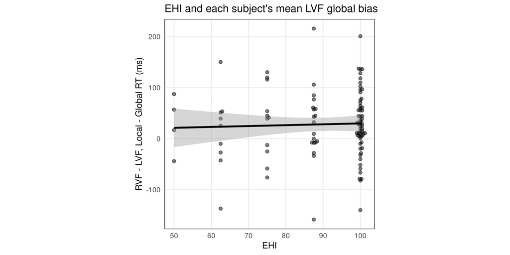

#### Statistics

First, test for a simple correlation between each subject’s EHI and LVF global bias.

Subject-level correlation: linear model

| term | estimate | std.error | statistic | p.value<sup>1</sup> |
| --- | --- | --- | --- | --- |
| (Intercept) | 12.746 | 40.809 | 0.312 | .76 |
| ehi | 0.173 | 0.449 | 0.386 | .7 |

<sup>1</sup> Two-sided

Subject-level correlation: Spearman's rho

| rho | statistic | p.value<sup>1</sup> | method | alternative |
| --- | --- | --- | --- | --- |
| 0.021 | 178,321.175 | .42 | Spearman's rank correlation rho | greater |

<sup>1</sup> One-sided

*In progress.* Model rt as a linear effect of field, level, and EHI (continuous):  
`rt_ehi_model <- lmer( rt ~ field:level:ehi + field:level + field:ehi + field + level + ehi + (1 | subject) )`  
*Discussion questions.* (1) Is this the right approach? (2) Should every interaction term be in this model? Even level:ehi? (3) Covariates not-of-interest? (4) How do you estimate the slope of the interaction effect in R? How do you report it?

```r
rt_ehi_model <- lmer(rt ~ field:level:ehi + field:level + field:ehi + field + level + ehi + (1 | subject), data = aah_for_rt_model)
```

```r
## Use anova() on competing models to test 2-way interaction.
interaction_stats <-
  function(model_with_interaction,
           model_with_no_interaction) {
    return(anova(model_with_interaction, model_with_no_interaction))
  }

rt_model_no_interaction <- update(rt_ehi_model, . ~ . - field:level:ehi)
interaction_anova <- interaction_stats(rt_model, rt_model_no_interaction)
interaction_anova |>
  as_tibble() |>
  rename(p.value = `Pr(>Chisq)`) |>
  format_p.value() |>
  pretty_table() |>
  tab_header(title = "Field by level by ehi interaction (RT)",
             subtitle = "ANOVA: compare models with vs. without interaction term")
```

Field by level by ehi interaction (RT)

ANOVA: compare models with vs. without interaction term

| npar | AIC | BIC | logLik | deviance | Chisq | Df | p.value |
| --- | --- | --- | --- | --- | --- | --- | --- |
| 6 | 169,486.498 | 169,531.086 | −84,737.249 | 169,474.498 | - | - | - |
| 8 | 169,489.576 | 169,549.026 | −84,736.788 | 169,473.576 | 0.922 | 2 | .63 |

```r
summary(rt_ehi_model)
```

```
## Linear mixed model fit by REML ['lmerMod']
## Formula: rt ~ field:level:ehi + field:level + field:ehi + field + level +
##     ehi + (1 | subject)
##    Data: aah_for_rt_model
##
## REML criterion at convergence: 169450.1
##
## Scaled residuals:
##       Min        1Q    Median        3Q       Max
## -4.730616 -0.605590 -0.158910  0.385007  6.564205
##
## Random effects:
##  Groups   Name        Variance Std.Dev.
##  subject  (Intercept) 29282.2  171.121
##  Residual             44973.9  212.070
## Number of obs: 12473, groups:  subject, 103
##
## Fixed effects:
##                            Estimate  Std. Error  t value
## (Intercept)             584.1403230 108.0464421  5.40638
## fieldLVF                 -2.2104396  33.3116792 -0.06636
## levelLocal               18.1029970  33.5246252  0.53999
## ehi                       1.1342479   1.1876567  0.95503
## fieldLVF:levelLocal      16.8711741  47.3988505  0.35594
## fieldLVF:ehi             -0.1551305   0.3660392 -0.42381
## fieldRVF:levelLocal:ehi  -0.1058441   0.3685927 -0.28716
## fieldLVF:levelLocal:ehi   0.0263287   0.3682342  0.07150
##
## Correlation of Fixed Effects:
##             (Intr) fldLVF lvlLcl ehi    flLVF:L flLVF: fRVF:L
## fieldLVF    -0.154
## levelLocal  -0.153  0.496
## ehi         -0.987  0.152  0.151
## fldLVF:lvlL  0.108 -0.703 -0.707 -0.107
## fieldLVF:eh  0.152 -0.987 -0.490 -0.154  0.694
## fldRVF:lvL:  0.151 -0.490 -0.987 -0.153  0.698   0.497
## fldLVF:lvL:  0.000  0.491  0.000  0.000 -0.698  -0.497  0.000
```

### Accuracy

#### Plots

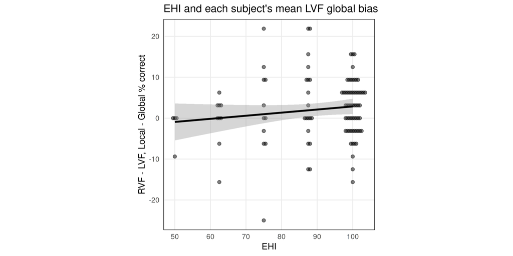

#### Statistics

First, test for a simple correlation between each subject’s EHI and LVF global bias.

Subject-level correlation: linear model

| term | estimate | std.error | statistic | p.value<sup>1</sup> |
| --- | --- | --- | --- | --- |
| (Intercept) | −4.71 | 4.885 | −0.964 | .34 |
| ehi | 0.076 | 0.054 | 1.411 | .16 |

<sup>1</sup> Two-sided

Subject-level correlation: Spearman's rho

| rho | statistic | p.value<sup>1</sup> | method | alternative |
| --- | --- | --- | --- | --- |
| 0.11 | 162,073.684 | .13 | Spearman's rank correlation rho | greater |

<sup>1</sup> One-sided

*In progress.* Model accuracy as a binomial effect of field, level, and EHI (continuous):  
`acc_ehi_model <- glmer( rt ~ field:level:ehi + field:level + field:ehi + field + level + ehi + (1 | subject) )`